# Entrega_Apple

Matias Corredoira

15/11/2020

## Introducción:

#### En este caso nos encontramos con una base de datos en la que se marcan las distintas cofras de ingresos a lo largo de los trimestres encontrados entre el año 2008 y el año 2017. Con este modelo, se tratará de hacer una comparativa realizando 2 modelos, el ARIMA y ETS.

### En primer lugar caragaremos las librerías que consideramos necesarias para la realización de la tarea.

```r
library(readr)
library(forecast)
library(xts)
library(ggplot2)
library(ggfortify)
```

## Cargaremos la base de datos necesaria para la realización de la tarea.

```r
rawData <- read.csv("IngresosApple.csv", sep=";", dec=",")
head(rawData)
```

```
##   Trimestre Ingresos
## 1   Q2 2008     7980
## 2   Q3 2008     7561
## 3   Q4 2008    11520
## 4   Q1 2009    11880
## 5   Q2 2009     9084
## 6   Q3 2009     9734
```

#### Realizamos la transformación oportuna en la columna Trimestre para que nos lo interprete como tal y así poder trabajar mejor los datos.

```r
rawDate <- seq(as.Date('2008/04/01'),as.Date('2017/09/30'),by ='quarter')
ventas_A <- rawData$Ingresos


ventas <- xts(ventas_A,order.by=rawDate)
ventas <- to.quarterly(ventas)
```

### Graficamos las ventas.

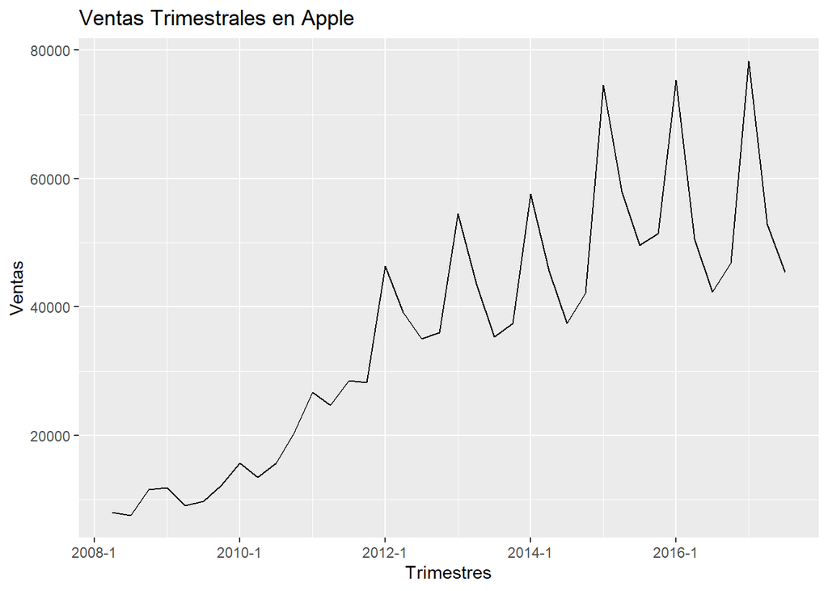

```r
autoplot(zVentas)+ggtitle("Ventas Trimestrales en Apple")+xlab("Trimestres")+ylab("Ventas")
```

### Graficamos las ventas de forma más precisa para que se pueddan distinguir bien los puntos donde se marcan los ingreso de los trimestre.

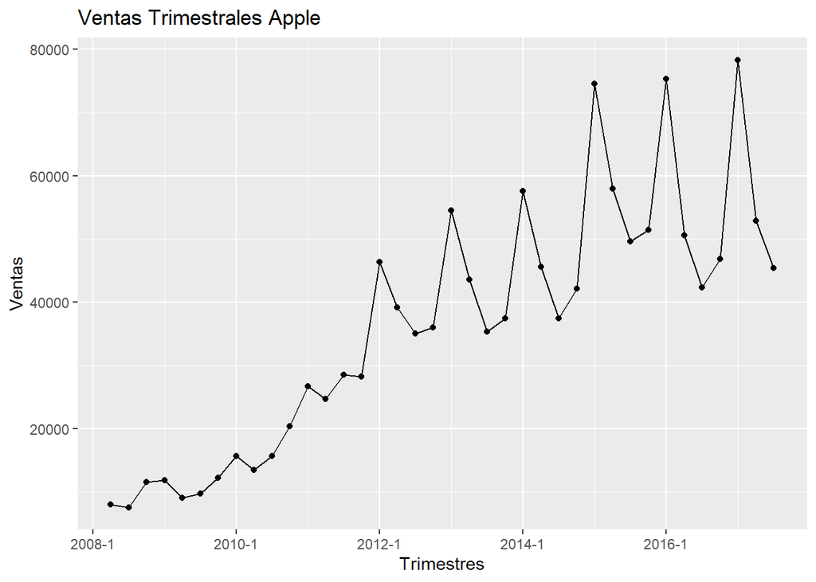

```r
df_new <- data.frame(value = as.vector(zVentas),
                     time = time(zVentas))
ggplot(df_new)+geom_point(aes(x=time,y=value))+geom_line(aes(x=time,y=value))+ylab("Ventas")+ggtitle("Ventas Trimestrales Apple")+xlab("Trimestres")
```

## Marcamos la separación de los años y realiazamos la gráfica por trimestres

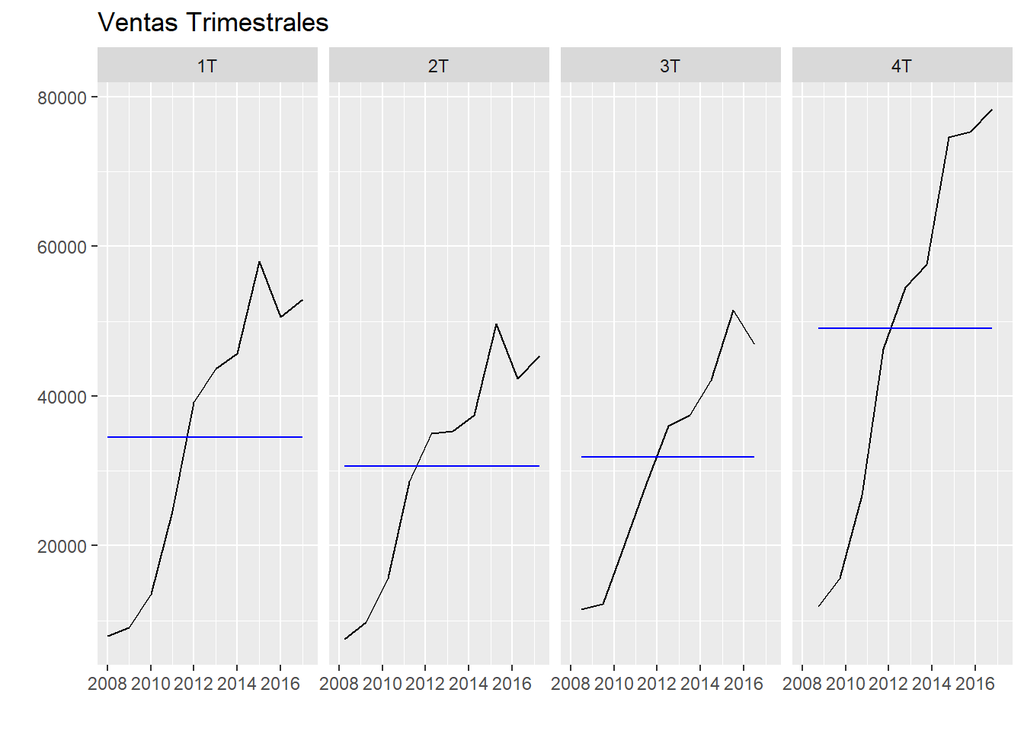

```r
tsVentas=ts(coredata(zVentas), start = c(2008, 1), frequency = 4)

ggfreqplot(tsVentas,freq=4,nrow=1,facet.labeller=c("1T","2T","3T","4T"))+ggtitle("Ventas Trimestrales")
```

##### Se puede comprobar como de forma clara los ingresos se concentran en el cuarto trimestre mientras que en los otros 3 los ingresos están bastante más equilibrados aunque en el primero las ventas sean ligeramente mayores. Esto podría ser indicativo de la existencia de estacionaridad.

## Series temporales: Componentes

```r
stl(tsVentas[,1], s.window = "periodic")
```

```
##  Call:
##  stl(x = tsVentas[, 1], s.window = "periodic")
##
## Components
##          seasonal     trend   remainder
## 2008 Q1 -1191.515 11987.713 -2816.19786
## 2008 Q2 -6202.795 11054.647  2709.14756
## 2008 Q3 -4388.396 10306.954  5601.44193
## 2008 Q4 11782.720  9712.795 -9615.51515
## 2009 Q1 -1191.515 10313.378   -37.86329
## 2009 Q2 -6202.795 11865.051  4071.74373
## 2009 Q3 -4388.396 12348.763  4246.63276
## 2009 Q4 11782.720 12927.130 -9026.85026
## 2010 Q1 -1191.515 14968.422  -277.90712
## 2010 Q2 -6202.795 18282.820  3619.97453
```

[output cut: 28 more lines]

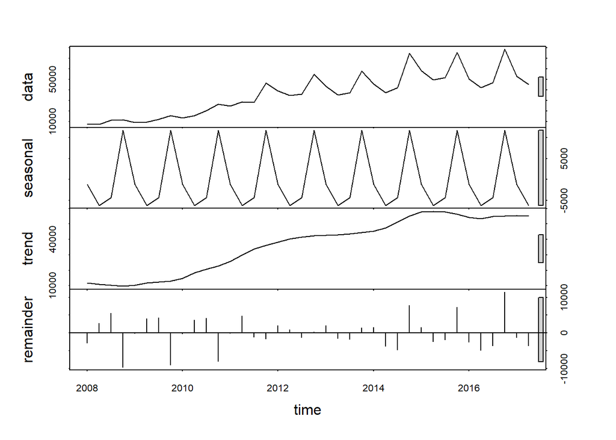

```r
plot(stl(tsVentas[,1], s.window = "periodic"))
```

##### En la siguiente gráfica sacamos muchos datos como las ventas anteriormente mostradas, la estacionaridad se marca de forma clara. Además también vemos como la tendencia al alza es clara, pero con el paso de los años se va viendo menos marcada.